# Práctica 1, Herramientas de programación para la ciencia de datos - R

Martín Híjar Jiménez

### Librerias

```r
library(readr)
library(janitor)
library(dplyr)
```

```r
library(ggplot2)
library(tidyr)
library(purrr)
```

### Borrar memoria

```r
rm(list=ls())
```

# Ejercicio 1

```r
df <- read_csv('mktmix.csv') # Cargar Datos en un dataframe
df <- clean_names(df) # Normalizar nombres de las columnas
```

# Ejercicio 2

```r
dimensions <- dim(df) # Devuelve dos números: 'filas columnas'
glimpse(df)
```

```
## Rows: 104
## Columns: 9
## $ new_vol_sales     <dbl> 19564, 19387, 23889, 20055, 20064, 19481, 19509, 190…
## $ base_price        <dbl> 15.02928, 15.02928, 14.58509, 15.33289, 15.64263, 15…
## $ radio             <dbl> 245, 314, 324, 298, 279, 259, 235, 290, 315, 318, 32…
## $ in_store          <dbl> 15.452, 16.388, 62.692, 16.573, 41.504, 20.404, 32.4…
## $ newspaper_inserts <chr> NA, NA, NA, NA, NA, NA, NA, NA, NA, NA, NA, NA, NA, …
## $ discount          <dbl> 0.00000000, 0.00000000, 0.05000000, 0.00000000, 0.04…
## $ tv                <dbl> 101.78000, 76.73400, 131.59020, 119.62706, 103.43812…
## $ stout             <dbl> 2.28342, 2.22134, 2.00604, 2.19897, 1.81860, 2.29155…
## $ website_campaign  <chr> NA, NA, NA, NA, NA, NA, NA, NA, NA, NA, NA, "Faceboo…
```

- Número de columnas: 9
- Número de filas: 104
- Clase de la columna ‘base_price’: dbl = double
- Clase de la columna ‘discount’: dbl = double

Las columnas ‘base_price’ y ’discount contienen números con decimales, representan el precio base y el descuento respectivamente.

# Ejercicio 3

```r
df <- df %>%
  mutate(newspaper_inserts=if_else(is.na(newspaper_inserts), 0, 1))

class(df$newspaper_inserts)
```

```
## [1] "numeric"
```

# Ejercicio 4

```r
#Leer los valores únicos de website_campaign
unique_values_website <- df %>%
  distinct(website_campaign) %>%
  na.omit()
#Lo anterior nos devuelve un dataframe, lo pasamos a vector
unique_values_website <- unique_values_website[[1]]

# Cambiamos los NA por 0
df <- df %>%
  mutate(website_campaign = ifelse(is.na(website_campaign), 0, website_campaign))


# Añadimos 3 columnas e indicamos 1 o 0 según se explica en el enunciado
df <- df %>%
  mutate('Facebook' = if_else(website_campaign == unique_values_website[1], 1, 0))

df <- df %>%
  mutate('Twitter' = if_else(website_campaign == unique_values_website[2], 1, 0))

df <- df %>%
  mutate('Website Campaign' = if_else(website_campaign == unique_values_website[3], 1, 0))
```

Hay 3 valores distintos: Facebook, Twitter y Website Campaign.

# Ejercicio 5

```r
facebook_weeks <- sum(df$Facebook)
twitter_weeks <- sum(df$Twitter)
```

Ha habido un total de 4 semanas para Facebook y otras 4 para Twitter.

# Ejercicio 6

```r
ej6_week <- df %>%
  filter(tv < 50) %>%
  nrow()
```

Ha habido 3 semanas con una inversión menor a 50

# Ejercicio 7

```r
df %>%
  group_by(is.na(radio)) %>%
  summarise(mean(tv))
```

| is.na(radio) | mean(tv) |
| --- | --- |
| FALSE | 140.2631 |
| TRUE | 159.6768 |

- MEDIA NOT NA ~ 140
- MEDIA NA ~ 160

La media de tv cuando radio es NA es mayor.

# Ejercicio 8

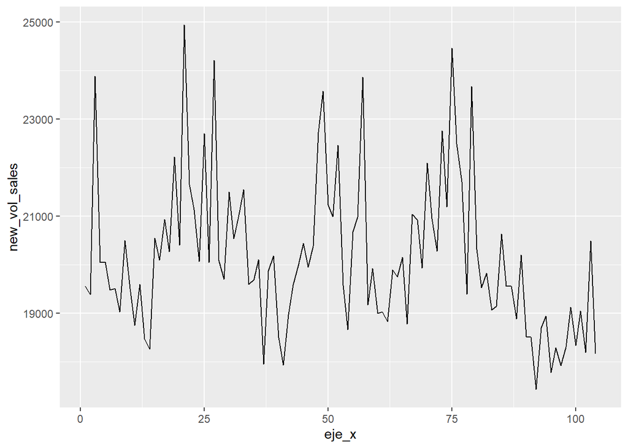

```r
eje_x <- c(1:nrow(df))

ggplot(df, aes(x=eje_x, y=new_vol_sales))+
  geom_line()
```

# Ejercicio 9

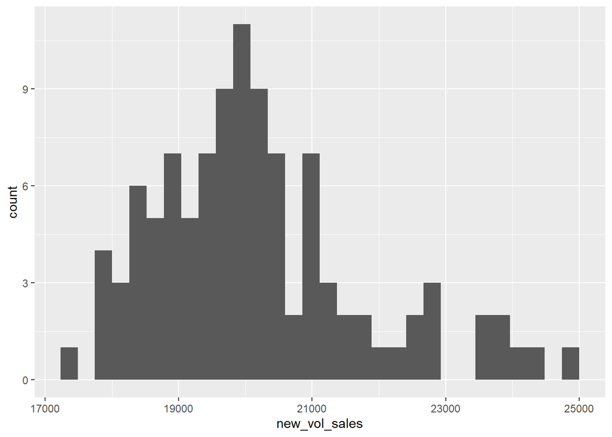

```r
ggplot(df, aes(x=new_vol_sales))+
  geom_histogram()
```

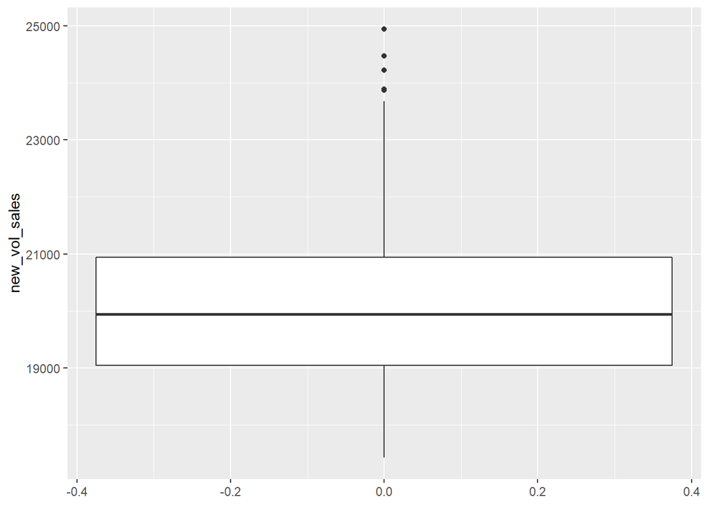

```r
ggplot(df, aes(y=new_vol_sales))+
  geom_boxplot()
```

Parece que la mediana es 20 000. Aparentemente la media será parecida a la mediana, igual un poco mayor, pero diría que son similares.

#Ejercicio 10

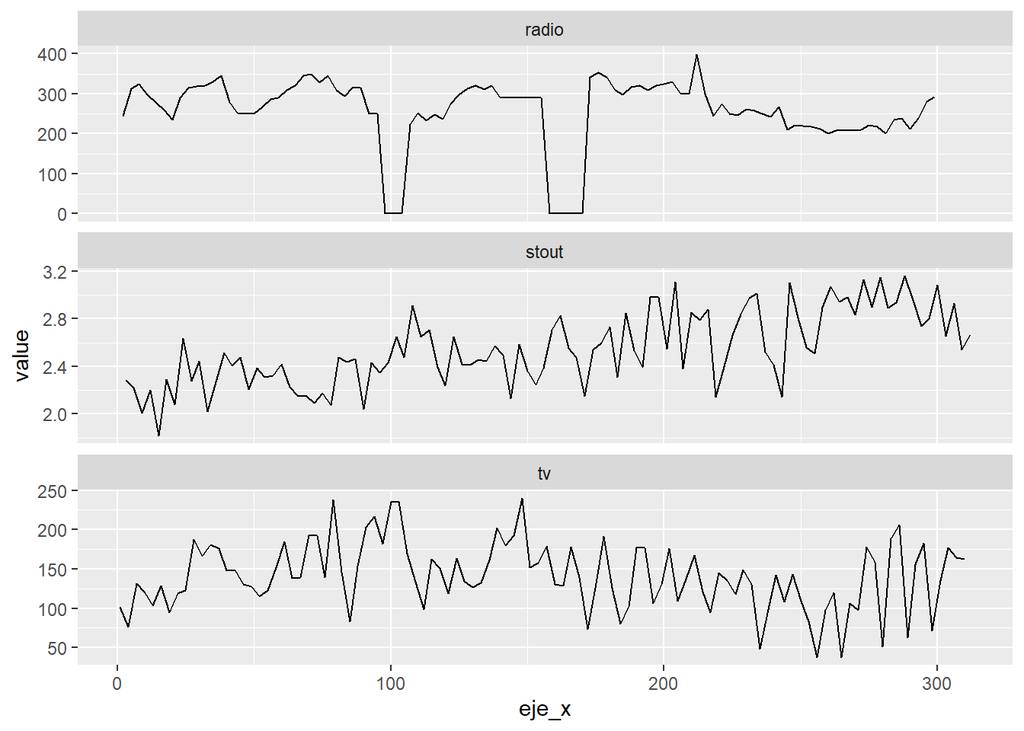

```r
df_ej10 <- df %>%
  select(tv, radio, stout)

df_media <- df_ej10 %>%
  pivot_longer(everything())

eje_x = c(1:nrow(df_media))

ggplot() +
  geom_line(data = df_media, aes(x = eje_x, y = value)) +
  facet_wrap(name~., scales = "free_y", ncol=1)
```

Vemos como el gasto en tv y stout están relativamente relacionados, mientras que la radio parece ir de una manera completamente independiente al resto de las variables.

# Ejercicio 11

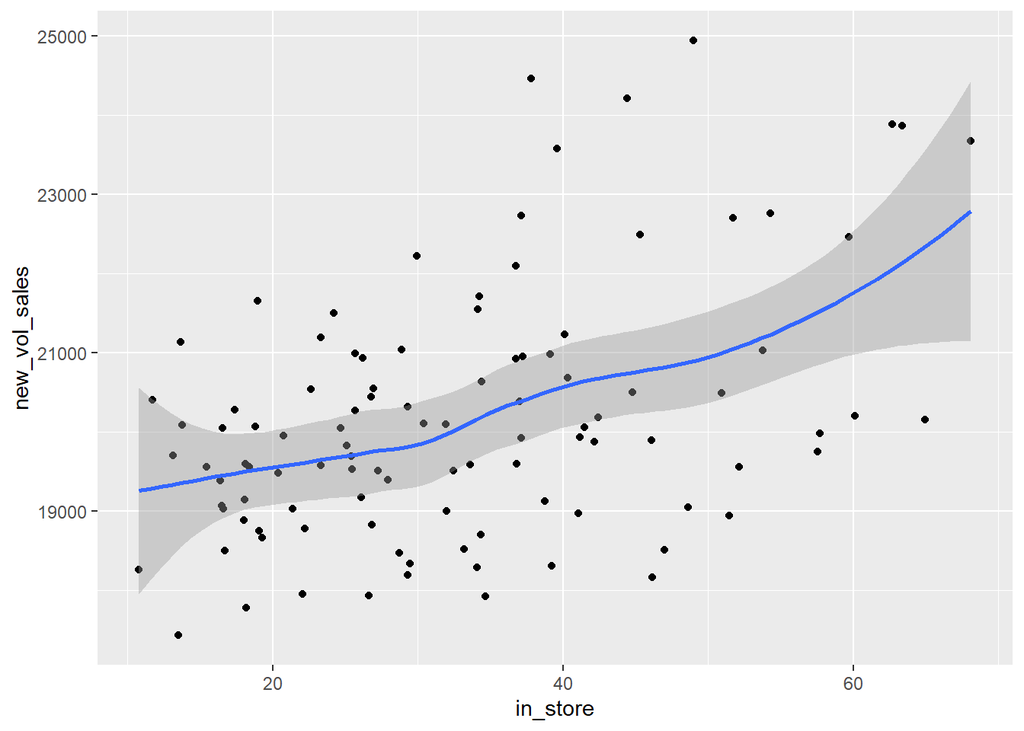

```r
ggplot()+
  geom_point(data = df, aes(y=new_vol_sales, x=in_store))+
  geom_smooth(data = df, aes(y=new_vol_sales, x=in_store))
```

Se ve claramente un tendencia alcista. Cuando la variable in_store aumenta, new_vol_sales también aumenta.

# Ejercicio 12

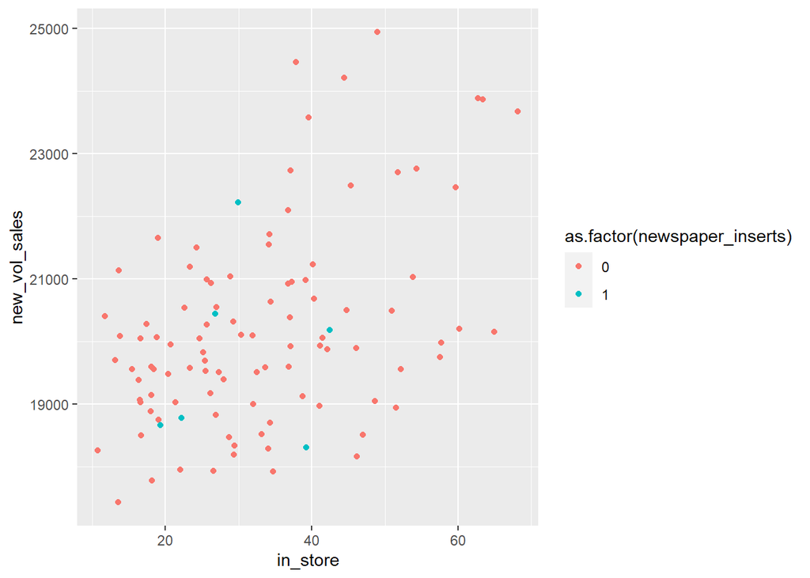

```r
# a)
ggplot()+
  geom_point(data = df, aes(y=new_vol_sales, x=in_store, color=as.factor(newspaper_inserts)))
```

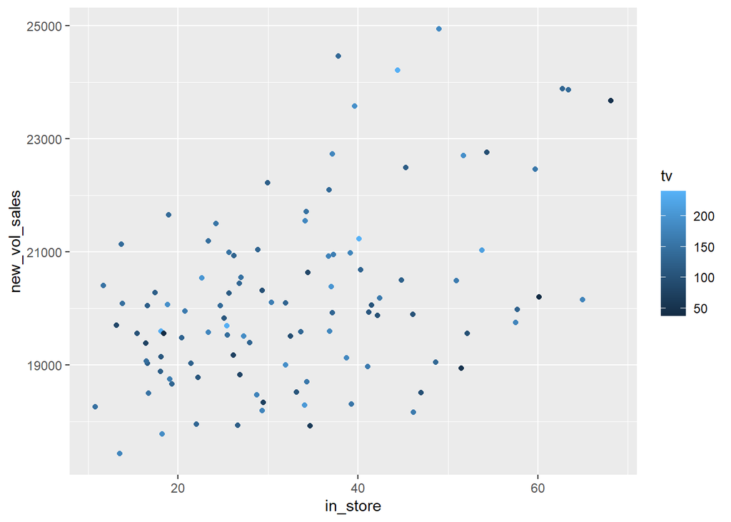

```r
# b)
ggplot()+
  geom_point(data = df, aes(y=new_vol_sales, x=in_store, color=tv))
```

# Ejercicio 13

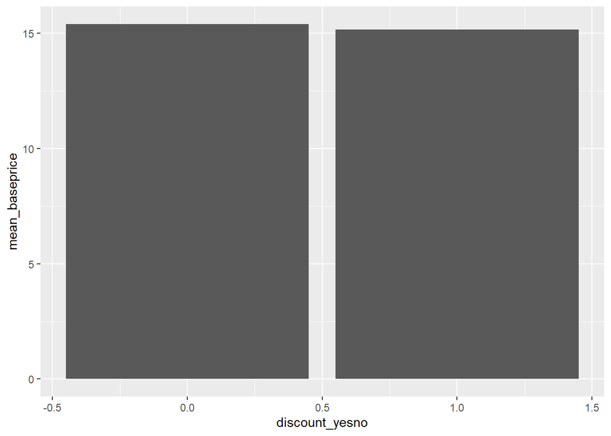

```r
df <- df %>%
  mutate('discount_yesno' = ifelse(discount > 0, 1, 0))


df %>%
  group_by(discount_yesno) %>%
  summarise(mean_baseprice = mean(base_price)) %>%
  ggplot()+
  geom_col(aes(x=discount_yesno, mean_baseprice))
```

# Ejercicio 14

```r
fun_ej14 <- function(x){

  df_aux <- df %>%
    select(x, new_vol_sales)


  # This code fits a linear regression model with all the variables
  # in df_aux, using new_vol_sales as target variable

  my_model <- lm(new_vol_sales ~ ., data = df_aux)
  # Value to be returned by the function, the adjusted R squared.
  summary(my_model)$adj.r.squared

}
input <- c("tv", "radio")
fun_ej14(input)
```

```
## Note: Using an external vector in selections is ambiguous.
## ℹ Use `all_of(x)` instead of `x` to silence this message.
## ℹ See <https://tidyselect.r-lib.org/reference/faq-external-vector.html>.
```

```
## [1] 0.01025529
```

# Ejercicio 15

```r
l_ej15 <- list( c("base_price", "radio", "tv", "stout"),
                c("base_price", "in_store", "discount", "radio", "tv", "stout"),
                c("in_store", "discount"))

r_cuadrado <- map_dbl(l_ej15, fun_ej14)
r_cuadrado
```

```
## [1] 0.6906219 0.7836765 0.2033219
```

El mejor es el segundo vector con un R Cuadrado de 0.784, seguido del primer vector (0.691 de R Cuadrado) y finalmente el tercer vector con 0.203 de R Cuadrado.